# Predicting Marketing-Campaign Response with a Decision Tree (CART)

**Business question:** Given customer attributes, who is most likely to respond to a marketing campaign — and how much of the campaign budget can be saved by contacting only the best-scoring customers?

*Structure adapted from the course CART template (Great Lakes, Business Analytics). Extended with ROC-AUC-based hyperparameter tuning, a lift / cumulative-gains analysis, customer-segment profiling and a targeting recommendation.*

## Results at a glance

|  | Result |
| --- | --- |
| Data | 20,000 customers, 8 predictors, **8.7%** responders |
| Why accuracy is not enough | Predicting "no response" for everyone already scores **90.9%** accuracy on the test set |
| Overfitting | Unpruned tree: 92.6% train vs 90.6% test. Pruned / tuned trees close the gap |
| Final model | Depth-5 tree (26 leaves), tuned by 5-fold CV on **ROC-AUC**; test AUC **0.767** (hand-pruned depth-13 tree: 0.731) |
| Targeting power (test set) | Contacting the **top 10%** of customers by score reaches ~**35%** of all responders; the **top 30%** reaches ~**64%** (**2.1x** lift over random targeting) |
| Recommendation | Prioritise customers with a short holding period, high SCR score, many credit transactions and self-employed occupation |

## 1. Load and check the data

```
Rows: 20,000 | Columns: 10
Missing values: 0
Overall response rate (Target = 1): 8.7%
```

|  | Cust_ID | Target | Age | Gender | Balance | Occupation | No_OF_CR_TXNS | AGE_BKT | SCR | Holding_Period |
| --- | --- | --- | --- | --- | --- | --- | --- | --- | --- | --- |
| 0 | C16505 | 0 | 41 | M | 91519.920 | SELF-EMP | 38 | 41-45 | 926 | 15 |
| 1 | C17241 | 0 | 52 | M | 117288.960 | SAL | 17 | >50 | 768 | 13 |
| 2 | C18802 | 0 | 31 | F | 259827.440 | SENP | 8 | 31-35 | 816 | 5 |
| 3 | C19289 | 0 | 45 | F | 26677.550 | PROF | 14 | 41-45 | 353 | 18 |
| 4 | C14028 | 0 | 39 | F | 43440.310 | SENP | 1 | 36-40 | 751 | 31 |

## 2. Prepare the data

- **`Cust_ID`** is a unique identifier (one value per row), so it carries no predictive signal. It is dropped.
- **`AGE_BKT`** is a bucketed copy of `Age`, so it is dropped to avoid duplicating information.
- **`Gender` and `Occupation`** are nominal categories with several levels, so they are one-hot encoded rather than given arbitrary numeric ranks.
- The data is split **70:30** into train and test sets. All model tuning uses the training set only; the test set is used once, for evaluation.

```
Train: 14,000 rows, 8.5% responders
Test : 6,000 rows, 9.1% responders
```

## 3. Baseline: why accuracy alone is misleading

Only about 9% of customers respond. A "model" that predicts *no response for everyone* would therefore already look very accurate. Any tree has to be judged against this baseline, and with ranking metrics (AUC, lift) that reflect how the model would actually be used to pick customers.

```
Baseline test accuracy (predict 'no response' for everyone): 90.9%
```

## 4. Three trees, compared

1. **Unpruned tree** (the course's starting model): grows until it memorises noise.
2. **Hand-pruned tree**: depth, split and leaf-size limits chosen by inspecting the tree.
3. **Tuned tree**: `GridSearchCV` with 5-fold cross-validation on the training set, scored on **ROC-AUC**. AUC is used instead of accuracy because with a 9% response rate, accuracy rewards models that simply predict "no".

```
Best parameters: {'criterion': 'gini', 'max_depth': 5, 'min_samples_leaf': 200, 'min_samples_split': 2}
Best 5-fold CV AUC (training data only): 0.757
```

| Model | Leaves | Train acc | Test acc | Train AUC | Test AUC | Acc gap (pts) | AUC gap |
| --- | --- | --- | --- | --- | --- | --- | --- |
| Unpruned | 410 | 0.926 | 0.906 | 0.919 | 0.681 | 2.038 | 0.238 |
| Hand-pruned (depth 13) | 126 | 0.918 | 0.913 | 0.840 | 0.731 | 0.543 | 0.109 |
| CV-tuned (final) | 26 | 0.915 | 0.909 | 0.780 | 0.767 | 0.598 | 0.013 |

```
Baseline accuracy to beat: 90.9%
```

**Reading the table**

- The unpruned tree fits the training data best but generalises worst (largest train-test gap).
- The hand-pruned tree fixes most of the accuracy gap, but at depth 13 it still has over 100 leaves and ranks customers worse on unseen data (lower test AUC).
- The CV-tuned tree is much simpler (26 leaves versus 126 and 410), overfits far less (small AUC gap) and has the **highest test AUC**. It is used as the final model.
- Test *accuracy* is almost identical for all three and close to the baseline, which is exactly why accuracy is the wrong yardstick here.

## 5. Evaluating the final model

**Confusion matrix at the default 0.5 cutoff.** A leaf only predicts "respond" when more than half of its customers responded. With a ~9% base rate, no leaf of the final tree reaches that level, so at the default cutoff the model **never flags anyone as a responder** (precision and recall are both 0). That does not make the model useless: its predicted *probabilities* still rank customers well, which is how it would be used in practice (Sections 6 and 7). The cell after the confusion matrix shows a workable operating point instead.

```
True negatives : 5,455
False positives: 0
False negatives: 545
True positives : 0
```

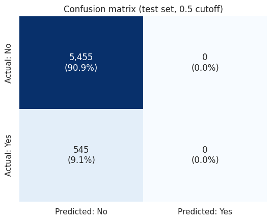

```
              precision    recall  f1-score   support

 No response       0.91      1.00      0.95      5455
    Response       0.00      0.00      0.00       545

    accuracy                           0.91      6000
   macro avg       0.45      0.50      0.48      6000
weighted avg       0.83      0.91      0.87      6000
```

**A workable operating point.** Instead of the 0.5 cutoff, flag the customers whose score is in the top 30%. This is the kind of cutoff a campaign team would actually choose.

```
Cutoff (probability): 0.107
Customers flagged  : 32.1% of the test set
Precision          : 18.8%  (responders among flagged customers; base rate is 9.1%)
Recall             : 66.4%  (share of all responders that are flagged)
```

**ROC curves on the test set.** The further a curve sits above the diagonal, the better the model separates responders from non-responders.

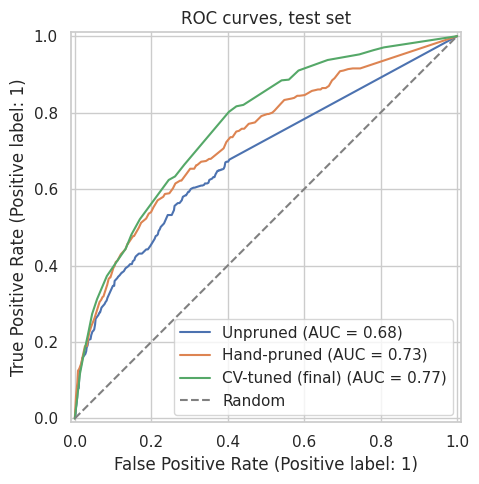

## 6. Lift and cumulative gains: how well does the model rank customers?

**What this does.** Instead of asking the tree for a yes/no answer, we take each test customer's *probability of responding*, sort customers from highest to lowest, and cut them into 10 equal groups (deciles). Then we check what really happened in each group, using the test-set outcomes the model never saw.

- **`response_rate`**: actual share of responders in the decile.
- **`lift`**: `response_rate / overall response rate`. A lift of 3 means that group responds 3x as often as an average customer; 1 means no better than random.
- **`cum_resp`**: share of *all* responders captured if you contact deciles 1 to N.
- **`cum_lift`**: cumulative capture divided by the share of customers contacted.

```
Test AUC: 0.767
Overall response rate in the test set: 9.1%
```

| decile | customers | responders | avg_prob | response_rate | lift | cum_cust | cum_resp | cum_lift |
| --- | --- | --- | --- | --- | --- | --- | --- | --- |
| 1 | 600 | 190 | 0.297 | 0.317 | 3.486 | 0.100 | 0.349 | 3.486 |
| 2 | 600 | 91 | 0.160 | 0.152 | 1.670 | 0.200 | 0.516 | 2.578 |
| 3 | 600 | 66 | 0.121 | 0.110 | 1.211 | 0.300 | 0.637 | 2.122 |
| 4 | 600 | 62 | 0.082 | 0.103 | 1.138 | 0.400 | 0.750 | 1.876 |
| 5 | 600 | 43 | 0.068 | 0.072 | 0.789 | 0.500 | 0.829 | 1.659 |
| 6 | 600 | 35 | 0.051 | 0.058 | 0.642 | 0.600 | 0.894 | 1.489 |
| 7 | 600 | 26 | 0.026 | 0.043 | 0.477 | 0.700 | 0.941 | 1.345 |
| 8 | 600 | 12 | 0.021 | 0.020 | 0.220 | 0.800 | 0.963 | 1.204 |
| 9 | 600 | 10 | 0.013 | 0.017 | 0.183 | 0.900 | 0.982 | 1.091 |
| 10 | 600 | 10 | 0.011 | 0.017 | 0.183 | 1.000 | 1.000 | 1.000 |

**Robustness check for tied scores.** A tree gives every customer in the same leaf the same probability, so a decile boundary can cut through a group of tied customers and the split is then arbitrary. To make sure the headline figures do not depend on that, we repeat the ranking 200 times with random tie-breaking and average the cumulative capture.

|  | % of customers contacted | % of responders captured (mean) | std across tie-breaks | lift vs random |
| --- | --- | --- | --- | --- |
| 0 | 10% | 0.352 | 0.004 | 3.524 |
| 1 | 20% | 0.518 | 0.002 | 2.589 |
| 2 | 30% | 0.638 | 0.003 | 2.127 |
| 3 | 40% | 0.755 | 0.006 | 1.888 |
| 4 | 50% | 0.837 | 0.004 | 1.674 |

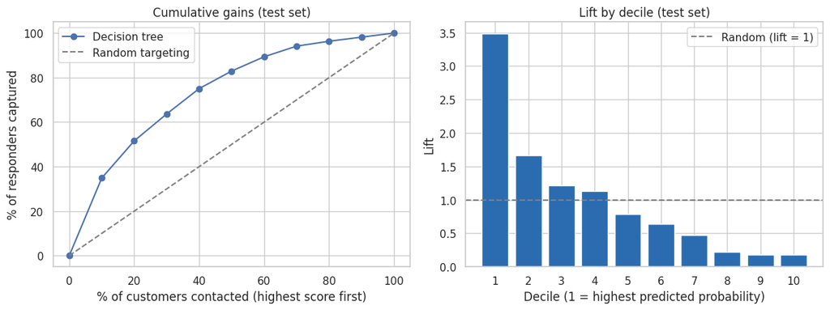

## 7. Who should be targeted?

Feature importance shows which variables drive the tree's splits. The rules below translate the highest-probability leaves into plain-English customer profiles, and the segment table compares the top-30% scored customers with everyone else.

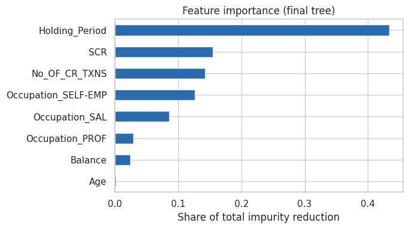

|  | importance |
| --- | --- |
| Holding_Period | 0.434 |
| SCR | 0.155 |
| No_OF_CR_TXNS | 0.143 |
| Occupation_SELF-EMP | 0.127 |
| Occupation_SAL | 0.086 |
| Occupation_PROF | 0.029 |
| Balance | 0.025 |
| Age | 0.002 |

```
Response rate 42% (313 customers): Holding_Period <= 10.5 AND Occupation_SELF-EMP > 0.5 AND SCR > 713.5

Response rate 38% (206 customers): Holding_Period <= 10.5 AND Occupation_SELF-EMP <= 0.5 AND No_OF_CR_TXNS > 22.5 AND Occupation_SAL <= 0.5 AND SCR > 608.0

Response rate 25% (203 customers): Holding_Period <= 10.5 AND Occupation_SELF-EMP > 0.5 AND SCR <= 713.5 AND No_OF_CR_TXNS > 17.5

Response rate 25% (215 customers): Holding_Period > 10.5 AND No_OF_CR_TXNS > 20.5 AND Holding_Period <= 18.5 AND Occupation_SAL <= 0.5 AND Occupation_PROF <= 0.5

(Occupation_* columns are 0/1 flags: '> 0.5' means the customer has that occupation.)
```

```
segment
Remaining 70%       4200
Top 30% by score    1800
```

| segment | Remaining 70% | Top 30% by score |
| --- | --- | --- |
| response_rate | 0.047 | 0.193 |
| median_holding_period | 18.000 | 7.000 |
| median_SCR | 507.000 | 717.500 |
| median_credit_txns | 12.000 | 24.000 |
| median_balance | 95580.295 | 48535.120 |
| share_self_employed | 0.112 | 0.302 |

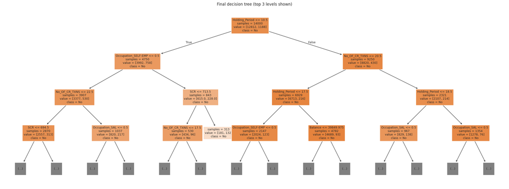

## 8. Campaign scenario and recommendation

|  | Contact top N% of customers | Customers contacted | Responders reached | % of all responders reached | Response rate among contacted | Contacts saved vs. mass mailing |
| --- | --- | --- | --- | --- | --- | --- |
| 0 | 10% | 600 | 190 | 0.349 | 0.317 | 0.900 |
| 1 | 20% | 1200 | 281 | 0.516 | 0.234 | 0.800 |
| 2 | 30% | 1800 | 347 | 0.637 | 0.193 | 0.700 |
| 3 | 40% | 2400 | 409 | 0.750 | 0.170 | 0.600 |
| 4 | 50% | 3000 | 452 | 0.829 | 0.151 | 0.500 |
| 5 | 60% | 3600 | 487 | 0.894 | 0.135 | 0.400 |

### Recommendation

- **Score every customer and contact in priority order** rather than mass-mailing the whole base. On the held-out test set, the top 30% of customers by score contained ~64% of all responders, so mailing 70% fewer customers would still reach roughly two thirds of the people who respond.
- **Best-fit profile:** short holding period, high SCR score, many credit transactions and self-employed occupation (Section 7).
- **Choose the cut-off with costs.** The right share of customers to contact depends on the cost per contact and the value of a response. The scenario table shows the trade-off at each level, and a cost-based cutoff is the natural next step.

### Limitations and next steps

- **Single 70:30 split.** Figures come from one held-out set of 6,000 customers (545 responders); repeated cross-validation would give confidence intervals.
- **Modest ranking power.** Test AUC is ~0.77. That is useful but far from perfect. At the default 0.5 cutoff the model flags no one, so it should be used as a score with a deliberately chosen cutoff, not as a yes/no classifier.
- **Tied scores.** A small tree produces a limited set of distinct probabilities, so deciles are coarse (see the tie-robust check in Section 6).
- **Correlation, not causation.** The tree describes who responded in the past, not what would make a new customer respond.
- **Next steps:** compare with a random forest or gradient boosting, tune the decision cutoff on campaign cost/benefit, and validate on a later campaign.